# Estatística no R

Maurício Bueno

2021-11-19

Esta disciplina tem como objetivo aprender a realizar análises estatísticas mais empregadas em pesquisas em psicologia, no ambiente de programação R. Inicialmente, vamos carregar (`install.packages()) e ativar (library()`) os pacotes que iremos utilizar na disciplina.

# Carregamento dos pacotes

```r
if(!require(tidyverse)) install.packages("tidyverse")
if(!require(psych)) install.packages("psych")
if(!require(knitr)) install.packages("knitr")
if(!require(kableExtra)) install.packages("kableExtra")
if(!require(expss)) install.packages("expss")
if(!require(janitor)) install.packages("janitor")
if(!require(pander)) install.packages('pander')
if(!require(arsenal)) install.packages('arsenal')
if(!require(moments)) install.packages('moments')
if(!require(readr)) install.packages('moments')
if(!require(readxl)) install.packages('readxl')
if(!require(descr)) install.packages("descr")
if(!require(rcompanion)) install.packages("rcompanion")
if(!require(rstatix)) install.packages("rstatix")
# Ativação dos pacotes ====

library(tidyverse)
library(pander)
library(janitor)
library(psych)
library(knitr)
library(arsenal)
library(rstatix)
library(GPArotation)
# library(kableExtra)
# library(expss)
# library(readxl)
# library(readr)
# library(corrplot)
```

# Importar banco de dados

Inicialmente vamos trabalhar com o banco de dados `dataset_mapfre.csv`, clique [aqui](https://docs.google.com/spreadsheets/d/1G0lQKeU0atMk3Q4wO5zz4HdvReRxKS68vx_Q0WbB37A/edit?usp=sharing) para baixá-lo. Esse banco de dados se refere ao artigo “[Sintomas de depressão e ansiedade em uma amostra representativa de universitários espanhóis, portugueses e brasileiros](https://drive.google.com/file/d/1qa0iCDm2DRvh3M6a2k7ENGahceDAlPIg/view?usp=sharing)”. Sugere-se a leitura desse artigo para a compreensão dos dados.

```r
dataset <- read.csv("dataset_mapfre.csv",encoding="UTF-8",stringsAsFactors=TRUE)

# OBS: Para que este comando funcione, é necessário que o arquivo csv esteja no diretório de trabalho do R.

# Observar o banco de dados
glimpse(dataset)
```

```
## Rows: 1,957
## Columns: 94
## $ country       <fct> SPAIN, SPAIN, SPAIN, SPAIN, SPAIN, SPAIN, SPAIN, SPAIN, ~
## $ sex           <fct> NA, NA, NA, NA, NA, NA, NA, M, M, M, M, M, M, M, M, M, M~
## $ age           <int> 18, NA, 26, NA, 20, NA, NA, 19, 21, 21, 23, 21, 22, 20, ~
## $ grado         <fct> "Educ.Infantil                                          ~
## $ curso_ou_ano  <int> 1, 2, 4, 3, 1, NA, 3, 1, 3, 3, 4, 4, 4, 2, 4, 3, 3, 1, 1~
## $ ceri_1        <int> 1, 1, 1, 2, 1, 2, 1, 1, 1, 2, 3, 2, 1, 1, 2, 1, 2, 2, 1,~
## $ ceri_2        <int> 1, 2, 1, 2, 3, 2, 3, 1, 1, 3, 2, 3, 2, 2, 2, 1, 3, 3, 3,~
## $ ceri_3        <int> 2, 2, 2, 1, 2, 2, 3, 2, 1, 2, 1, 3, 2, 3, 2, 1, 3, 1, 2,~
## $ ceri_4        <int> 1, 1, 1, 2, 1, 1, 2, 1, 1, 3, 3, 3, 1, 2, 3, 1, 2, 1, 2,~
## $ ceri_5        <int> NA, 1, 2, 1, NA, 2, 2, 1, 1, 3, 1, 2, 2, 1, 2, 1, 2, 1, ~
## $ ceri_6        <int> 2, 2, 1, 2, 1, 1, 2, 1, 2, 1, 4, 3, 3, 2, 3, 2, 2, 2, 1,~
## $ ceri_7        <int> 1, 1, 1, 1, 1, 2, 2, 1, 1, 2, 2, 1, 1, 2, 1, 1, 2, 1, 1,~
## $ ceri_8        <int> 1, 1, 1, 1, 2, 1, 2, 1, 1, 1, 1, 1, 1, 2, 2, 1, 2, 1, 1,~
```

[output cut: 81 more lines]

# Estatística descritiva

## Frequências

```r
# Função count()
dataset %>%
  filter(!is.na(sex)) %>%
  group_by(sex) %>%
  count(country) %>%
  mutate(porc = n/sum(n)*100) %>%
  pander()
```

| sex | country | n | porc |
| --- | --- | --- | --- |
| F | BRAZIL | 166 | 13.67 |
| F | PORTUGAL | 223 | 18.37 |
| F | SPAIN | 825 | 67.96 |
| M | BRAZIL | 149 | 20.24 |
| M | PORTUGAL | 203 | 27.58 |
| M | SPAIN | 384 | 52.17 |

```r
# usando a função tabyl() do pacote janitor
# contar quantas pessoas de cada país.

dataset %>%             # pegar o dataframe dataset
  tabyl(country) %>%    # use a função tabyl para tabular as categorias de país
  pander()              # utilize o pander para fazer a tabela
```

| country | n | percent |
| --- | --- | --- |
| BRAZIL | 315 | 0.161 |
| PORTUGAL | 426 | 0.2177 |
| SPAIN | 1216 | 0.6214 |

```r
dataset %>%             # pegar o dataframe dataset
  tabyl(country) %>%    # use a função tabyl para tabular as categorias de país
  adorn_totals() %>%    # acrescente uma linha com os totais
  pander()              # utilize o pander para fazer a tabela
```

| country | n | percent |
| --- | --- | --- |
| BRAZIL | 315 | 0.161 |
| PORTUGAL | 426 | 0.2177 |
| SPAIN | 1216 | 0.6214 |
| Total | 1957 | 1 |

```r
# contar por gênero e país (retirando NAs)
dataset %>%
  filter(!is.na(sex)) %>%
  tabyl(sex,country) %>%
  adorn_totals() %>%
  pander()
```

| sex | BRAZIL | PORTUGAL | SPAIN |
| --- | --- | --- | --- |
| F | 166 | 223 | 825 |
| M | 149 | 203 | 384 |
| Total | 315 | 426 | 1209 |

```r
# contar por gênero e país, acrescentando funções
dataset %>%
  filter(!is.na(sex)) %>%
  tabyl(country,sex) %>%           # função de tabulação do janitor
  adorn_totals(c("row","col")) %>% # adiciona o N
  adorn_percentages("row") %>%     # adiciona porcentagens
  adorn_pct_formatting(
    rounding = "half up",          # arredondar do cinco pra cima
    digits = 0) %>%                # número de casas decimais
  adorn_ns() %>%                   # mostra N e % juntas
  pander()                         # melhora a visualização dos dados.
```

| country | F | M | Total |
| --- | --- | --- | --- |
| BRAZIL | 53% (166) | 47% (149) | 100% (315) |
| PORTUGAL | 52% (223) | 48% (203) | 100% (426) |
| SPAIN | 68% (825) | 32% (384) | 100% (1209) |
| Total | 62% (1214) | 38% (736) | 100% (1950) |

```r
# adição de um qui-quadrado para a distribuição
# para rodar essa análise tem que tirar os totais.

# dataset %>%
  # filter(!is.na(sex)) %>%
  # tabyl(country,sex) %>%           # função de tabulação do janitor
  # adorn_totals(c("row","col")) %>% # adiciona o N
  # chisq.test()
  # pander()                         # melhora a visualização dos dados.
```

#### Exercício

Utilize o dataframe `dataset` para realizar os exercícios abaixo:

1. Crie uma tabela de frequências dos cursos (grado) dos participantes.
2. Crie uma tabela de frequências dos cursos dos participantes, por sexo, com totais.

## Medidas de tendência central e de dispersão

A descrição dos dados geralmente é realizada pelas seguintes estatísticas: Média, desvio padrão, mediana, amplitude, mínimo, máximo, assimetria e curtose. Para calculá-las podemos usar funções específicas para cada uma ou funções que realizam um conjunto de análises descritivas.

### Funções específicas

```r
## mean()
mean(dataset$age, na.rm = TRUE)
```

```
## [1] 21.46034
```

```r
## sd()
sd(dataset$age, na.rm = TRUE)
```

```
## [1] 3.828075
```

```r
## median()
median(dataset$age, na.rm = TRUE)
```

```
## [1] 21
```

```r
## min()
min(dataset$age, na.rm = TRUE)
```

```
## [1] 17
```

```r
## max()
max(dataset$age, na.rm = TRUE)
```

```
## [1] 68
```

```r
## range()
range(dataset$age, na.rm = TRUE)
```

```
## [1] 17 68
```

```r
## skewness()
moments::skewness(dataset$age, na.rm = TRUE) # pacote moments
```

```
## [1] 5.018834
```

```r
skew(dataset$age, na.rm = TRUE)              # pacote psych
```

```
## [1] 5.014931
```

```r
## kurtosis()
moments::kurtosis(dataset$age, na.rm = TRUE) # pacote moments
```

```
## [1] 44.35922
```

```r
kurtosi(dataset$age, na.rm = TRUE)           # pacote psych
```

```
## [1] 41.31324
```

#### Exercícios

Calcule as estatísticas descritivas: média, desvio padrão, mediana, valores mínimo e máximo, amplitude, assimetria e curtose das pontuações em depressão (bdi_sum) e ansiedade (bai_sum). Crie uma tabela (dataframe) com esses valores.

# Distribuição normal

A distribuição normal (ou distribuição de Gauss) é uma distribuição de probabilidades, isto é ela indica a probabilidade de um certo valor ser obtido. Uma **distribuição normal padrão** apresenta médial igual a zero e desvio padrão igual a 1. A média fica no centro da distribuição e coincide com a mediana, separando a amostra em duas metades. Quando a curtose (achatamento) e assimetria (distribuição lateral) são diferentes de zero, a distribuição começa a se afastar da normal.

# Funções que sumariam dados

```r
# describe() {psych}
describe(dataset$age, na.rm = TRUE) %>% pander()
```

Table continues below

|  | vars | n | mean | sd | median | trimmed | mad | min | max |
| --- | --- | --- | --- | --- | --- | --- | --- | --- | --- |
| **X1** | 1 | 1929 | 21.46 | 3.828 | 21 | 20.94 | 2.965 | 17 | 68 |

|  | range | skew | kurtosis | se |
| --- | --- | --- | --- | --- |
| **X1** | 51 | 5.015 | 41.31 | 0.08716 |

```r
describe(dataset$age, na.rm = TRUE) %>% kable(format = "markdown")
```

|  | vars | n | mean | sd | median | trimmed | mad | min | max | range | skew | kurtosis | se |
| --- | --- | --- | --- | --- | --- | --- | --- | --- | --- | --- | --- | --- | --- |
| X1 | 1 | 1929 | 21.46034 | 3.828075 | 21 | 20.93528 | 2.9652 | 17 | 68 | 51 | 5.014931 | 41.31324 | 0.0871594 |

```r
# summary() {base}
dataset %>% select(age) %>% summary()
```

```
##       age
##  Min.   :17.00
##  1st Qu.:19.00
##  Median :21.00
##  Mean   :21.46
##  3rd Qu.:22.00
##  Max.   :68.00
##  NA's   :28
```

```r
# tableby() {arsenal}
tableby(country ~ bdi_sum + bai_sum, # calcule as descritivas de bdi e bai por country
        test = FALSE,                # se FALSE,  não faz teste de significância
        data = dataset) %>%          # especificar base de dados
  summary(text=TRUE)                 # tem que colocar text=TRUE senão aparecem uns códigos estranhos porque o R entende o espaço como código.                                            Assim a tabela fica bacaninha.
```

```
##
##
## |             | BRAZIL (N=315) | PORTUGAL (N=426) | SPAIN (N=1216) | Total (N=1957) |
## |:------------|:--------------:|:----------------:|:--------------:|:--------------:|
## |bdi_sum      |                |                  |                |                |
## |-  N-Miss    |       1        |        3         |       4        |       8        |
## |-  Mean (SD) | 10.895 (8.294) |  9.054 (7.727)   | 8.859 (7.537)  | 9.229 (7.736)  |
## |-  Range     | 0.000 - 41.000 |  0.000 - 53.000  | 0.000 - 57.000 | 0.000 - 57.000 |
## |bai_sum      |                |                  |                |                |
## |-  N-Miss    |       0        |        2         |       3        |       5        |
## |-  Mean (SD) | 9.013 (8.403)  |  7.915 (8.042)   | 8.547 (8.057)  | 8.485 (8.114)  |
## |-  Range     | 0.000 - 46.000 |  0.000 - 45.000  | 0.000 - 48.000 | 0.000 - 48.000 |
```

```r
## mesma função mas para a variável sexo.
tableby(sex ~ bdi_sum + bai_sum,
        test = FALSE,
        data = dataset) %>%
  summary(text=TRUE)
```

```
##
##
## |             |   F (N=1214)   |   M (N=736)    | Total (N=1950) |
## |:------------|:--------------:|:--------------:|:--------------:|
## |bdi_sum      |                |                |                |
## |-  N-Miss    |       4        |       4        |       8        |
## |-  Mean (SD) | 9.588 (7.725)  | 8.676 (7.737)  | 9.244 (7.740)  |
## |-  Range     | 0.000 - 53.000 | 0.000 - 57.000 | 0.000 - 57.000 |
## |bai_sum      |                |                |                |
## |-  N-Miss    |       0        |       5        |       5        |
## |-  Mean (SD) | 9.470 (8.446)  | 6.813 (7.142)  | 8.471 (8.082)  |
## |-  Range     | 0.000 - 48.000 | 0.000 - 44.000 | 0.000 - 48.000 |
```

```r
## Pode descrever apenas uma variável em função de sexo
tableby(sex ~ age, data = dataset) %>% summary(text = TRUE)
```

```
##
##
## |             |   F (N=1214)    |    M (N=736)    | Total (N=1950)  | p value|
## |:------------|:---------------:|:---------------:|:---------------:|-------:|
## |age          |                 |                 |                 |   0.155|
## |-  N-Miss    |        8        |       16        |       24        |        |
## |-  Mean (SD) | 21.556 (4.106)  | 21.300 (3.308)  | 21.461 (3.829)  |        |
## |-  Range     | 17.000 - 68.000 | 17.000 - 48.000 | 17.000 - 68.000 |        |
```

```r
## Pode descrever somenta a variável contínua sem ser em função de alguma outra variável.
tableby( ~ age + bdi_sum + bai_sum, data = dataset) %>% summary(text = TRUE)
```

```
##
##
## |             | Overall (N=1957) |
## |:------------|:----------------:|
## |age          |                  |
## |-  N-Miss    |        28        |
## |-  Mean (SD) |  21.460 (3.828)  |
## |-  Range     | 17.000 - 68.000  |
## |bdi_sum      |                  |
## |-  N-Miss    |        8         |
## |-  Mean (SD) |  9.229 (7.736)   |
## |-  Range     |  0.000 - 57.000  |
## |bai_sum      |                  |
## |-  N-Miss    |        5         |
## |-  Mean (SD) |  8.485 (8.114)   |
## |-  Range     |  0.000 - 48.000  |
```

```r
## Também pode dar as médias em função do sexo, estratificado por país
tableby(sex ~ age + bdi_sum + bai_sum, data = dataset, strata = country) %>% summary(text = TRUE)
```

```
##
##
## |country  |             |   F (N=1214)    |    M (N=736)    | Total (N=1950)  | p value |
## |:--------|:------------|:---------------:|:---------------:|:---------------:|:-------:|
## |BRAZIL   |age          |                 |                 |                 |  0.130  |
## |         |-  N-Miss    |        6        |       16        |       22        |         |
## |         |-  Mean (SD) | 23.406 (8.865)  | 22.128 (4.314)  | 22.826 (7.184)  |         |
## |         |-  Range     | 17.000 - 68.000 | 17.000 - 41.000 | 17.000 - 68.000 |         |
## |         |bdi_sum      |                 |                 |                 |  0.004  |
## |         |-  N-Miss    |        1        |        0        |        1        |         |
## |         |-  Mean (SD) | 12.158 (8.534)  |  9.497 (7.812)  | 10.895 (8.294)  |         |
## |         |-  Range     | 0.000 - 41.000  | 0.000 - 38.000  | 0.000 - 41.000  |         |
## |         |bai_sum      |                 |                 |                 |  0.148  |
## |         |-  Mean (SD) |  9.663 (8.708)  |  8.289 (8.017)  |  9.013 (8.403)  |         |
## |         |-  Range     | 0.000 - 46.000  | 0.000 - 44.000  | 0.000 - 46.000  |         |
## |PORTUGAL |age          |                 |                 |                 |  0.387  |
## |         |-  Mean (SD) | 20.368 (1.684)  | 20.507 (1.642)  | 20.434 (1.664)  |         |
## |         |-  Range     | 18.000 - 23.000 | 18.000 - 23.000 | 18.000 - 23.000 |         |
## |         |bdi_sum      |                 |                 |                 |  0.252  |
## |         |-  N-Miss    |        1        |        2        |        3        |         |
## |         |-  Mean (SD) |  9.464 (7.421)  |  8.602 (8.047)  |  9.054 (7.727)  |         |
## |         |-  Range     | 0.000 - 53.000  | 0.000 - 52.000  | 0.000 - 53.000  |         |
## |         |bai_sum      |                 |                 |                 | < 0.001 |
## |         |-  N-Miss    |        0        |        2        |        2        |         |
## |         |-  Mean (SD) |  9.498 (8.449)  |  6.159 (7.188)  |  7.915 (8.042)  |         |
## |         |-  Range     | 0.000 - 45.000  | 0.000 - 42.000  | 0.000 - 45.000  |         |
## |SPAIN    |age          |                 |                 |                 |  0.643  |
## |         |-  N-Miss    |        2        |        0        |        2        |         |
## |         |-  Mean (SD) | 21.519 (2.775)  | 21.432 (3.481)  | 21.491 (3.016)  |         |
## |         |-  Range     | 18.000 - 43.000 | 18.000 - 48.000 | 18.000 - 48.000 |         |
## |         |bdi_sum      |                 |                 |                 |  0.128  |
## |         |-  N-Miss    |        2        |        2        |        4        |         |
## |         |-  Mean (SD) |  9.106 (7.542)  |  8.395 (7.537)  |  8.880 (7.544)  |         |
## |         |-  Range     | 0.000 - 53.000  | 0.000 - 57.000  | 0.000 - 57.000  |         |
## |         |bai_sum      |                 |                 |                 | < 0.001 |
## |         |-  N-Miss    |        0        |        3        |        3        |         |
## |         |-  Mean (SD) |  9.424 (8.402)  |  6.580 (6.680)  |  8.526 (8.006)  |         |
## |         |-  Range     | 0.000 - 48.000  | 0.000 - 42.000  | 0.000 - 48.000  |         |
```

```r
## ou o contrário
tableby(country ~ age + bdi_sum + bai_sum, data = dataset, strata = sex) %>% summary(text = TRUE)
```

```
##
##
## |sex |             | BRAZIL (N=315)  | PORTUGAL (N=426) | SPAIN (N=1209)  | Total (N=1950)  | p value |
## |:---|:------------|:---------------:|:----------------:|:---------------:|:---------------:|:-------:|
## |F   |age          |                 |                  |                 |                 | < 0.001 |
## |    |-  N-Miss    |        6        |        0         |        2        |        8        |         |
## |    |-  Mean (SD) | 23.406 (8.865)  |  20.368 (1.684)  | 21.519 (2.775)  | 21.556 (4.106)  |         |
## |    |-  Range     | 17.000 - 68.000 | 18.000 - 23.000  | 18.000 - 43.000 | 17.000 - 68.000 |         |
## |    |bdi_sum      |                 |                  |                 |                 | < 0.001 |
## |    |-  N-Miss    |        1        |        1         |        2        |        4        |         |
## |    |-  Mean (SD) | 12.158 (8.534)  |  9.464 (7.421)   |  9.106 (7.542)  |  9.588 (7.725)  |         |
## |    |-  Range     | 0.000 - 41.000  |  0.000 - 53.000  | 0.000 - 53.000  | 0.000 - 53.000  |         |
## |    |bai_sum      |                 |                  |                 |                 |  0.945  |
## |    |-  Mean (SD) |  9.663 (8.708)  |  9.498 (8.449)   |  9.424 (8.402)  |  9.470 (8.446)  |         |
## |    |-  Range     | 0.000 - 46.000  |  0.000 - 45.000  | 0.000 - 48.000  | 0.000 - 48.000  |         |
## |M   |age          |                 |                  |                 |                 | < 0.001 |
## |    |-  N-Miss    |       16        |        0         |        0        |       16        |         |
## |    |-  Mean (SD) | 22.128 (4.314)  |  20.507 (1.642)  | 21.432 (3.481)  | 21.300 (3.308)  |         |
## |    |-  Range     | 17.000 - 41.000 | 18.000 - 23.000  | 18.000 - 48.000 | 17.000 - 48.000 |         |
## |    |bdi_sum      |                 |                  |                 |                 |  0.334  |
## |    |-  N-Miss    |        0        |        2         |        2        |        4        |         |
## |    |-  Mean (SD) |  9.497 (7.812)  |  8.602 (8.047)   |  8.395 (7.537)  |  8.676 (7.737)  |         |
## |    |-  Range     | 0.000 - 38.000  |  0.000 - 52.000  | 0.000 - 57.000  | 0.000 - 57.000  |         |
## |    |bai_sum      |                 |                  |                 |                 |  0.014  |
## |    |-  N-Miss    |        0        |        2         |        3        |        5        |         |
## |    |-  Mean (SD) |  8.289 (8.017)  |  6.159 (7.188)   |  6.580 (6.680)  |  6.813 (7.142)  |         |
## |    |-  Range     | 0.000 - 44.000  |  0.000 - 42.000  | 0.000 - 42.000  | 0.000 - 44.000  |         |
```

```r
## Interação entre variáveis nominais

tableby(interaction(sex, country) ~ bdi_sum + bai_sum,
        test = FALSE,
        data = dataset) %>%
  summary(text = TRUE)
```

```
##
##
## |             | F.BRAZIL (N=166) | M.BRAZIL (N=149) | F.PORTUGAL (N=223) | M.PORTUGAL (N=203) | F.SPAIN (N=825) | M.SPAIN (N=384) | Total (N=1950) |
## |:------------|:----------------:|:----------------:|:------------------:|:------------------:|:---------------:|:---------------:|:--------------:|
## |bdi_sum      |                  |                  |                    |                    |                 |                 |                |
## |-  N-Miss    |        1         |        0         |         1          |         2          |        2        |        2        |       8        |
## |-  Mean (SD) |  12.158 (8.534)  |  9.497 (7.812)   |   9.464 (7.421)    |   8.602 (8.047)    |  9.106 (7.542)  |  8.395 (7.537)  | 9.244 (7.740)  |
## |-  Range     |  0.000 - 41.000  |  0.000 - 38.000  |   0.000 - 53.000   |   0.000 - 52.000   | 0.000 - 53.000  | 0.000 - 57.000  | 0.000 - 57.000 |
## |bai_sum      |                  |                  |                    |                    |                 |                 |                |
## |-  N-Miss    |        0         |        0         |         0          |         2          |        0        |        3        |       5        |
## |-  Mean (SD) |  9.663 (8.708)   |  8.289 (8.017)   |   9.498 (8.449)    |   6.159 (7.188)    |  9.424 (8.402)  |  6.580 (6.680)  | 8.471 (8.082)  |
## |-  Range     |  0.000 - 46.000  |  0.000 - 44.000  |   0.000 - 45.000   |   0.000 - 42.000   | 0.000 - 48.000  | 0.000 - 42.000  | 0.000 - 48.000 |
```

# Representações gráficas

### Gráficos de barras

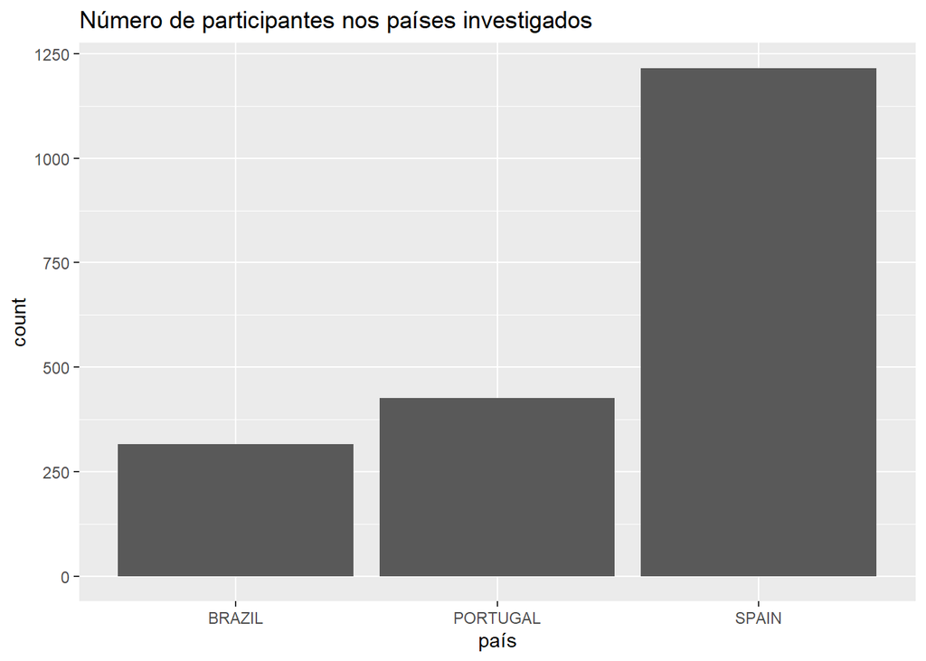

```r
ggplot(dataset, aes(x = country)) +
  geom_bar() +
  labs(x = "país",
       title = "Número de participantes nos países investigados")
```

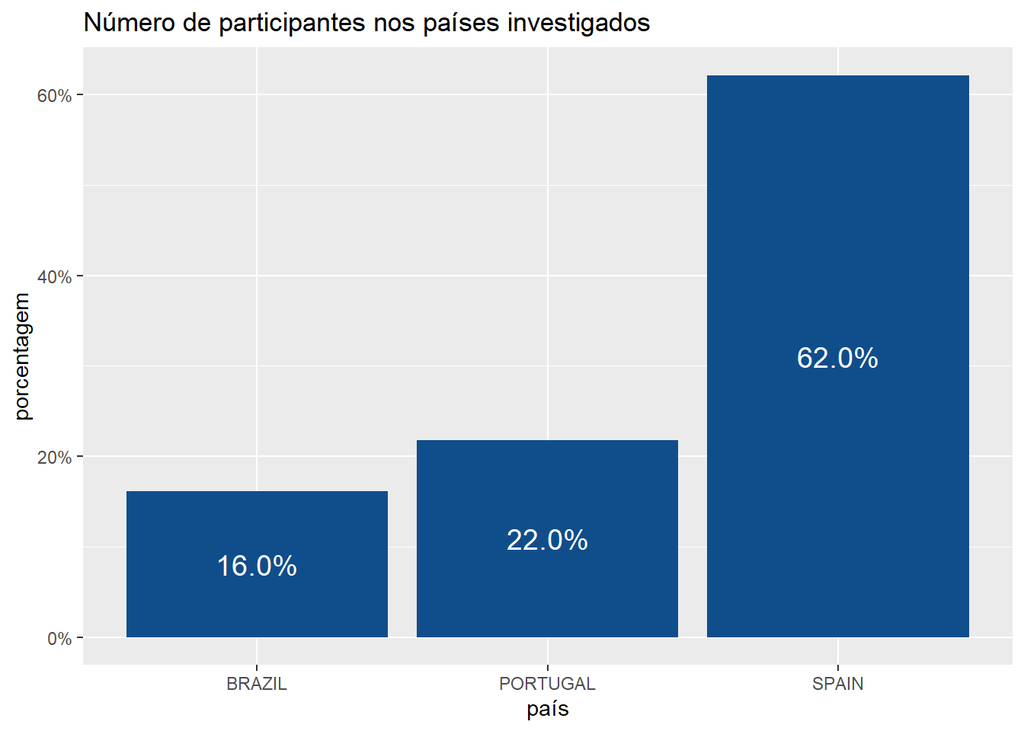

```r
# alterando o eixo y para ser a % ao invés do N
ggplot(dataset, aes(x = country, y = ..prop.., group = 1)) +
  geom_bar(stat = "count",fill = "dodgerblue4") +
  geom_text(aes(label = scales::percent(round(..prop..,2)),
                y = ..prop..),
            stat = "count",
            color = "white",
            size = 5,
            position = position_stack(vjust = 0.5)) +
  scale_y_continuous(labels = scales::percent_format()) +
  labs(x = "país",
       y = "porcentagem",
       title = "Número de participantes nos países investigados")
```

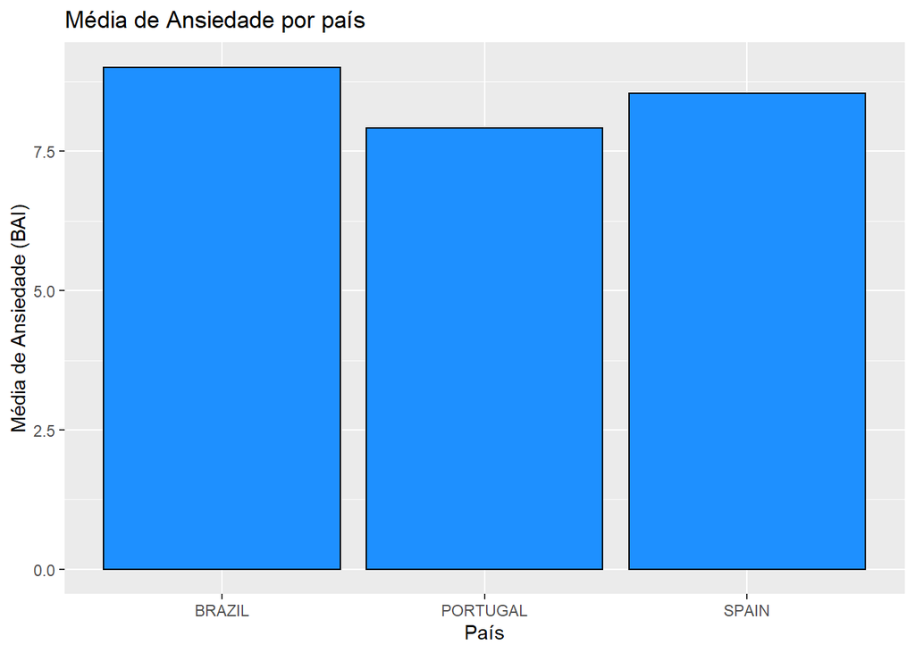

```r
# Alterando argumentos
ggplot(dataset,
       aes(x=country, y=bai_sum)) +
  geom_bar(stat = "summary",
           fun = mean,
           fill = "dodgerblue",
           color = "black",
           na.rm = TRUE) +
  labs(title = "Média de Ansiedade por país",
       x = "País", y = "Média de Ansiedade (BAI)")
```

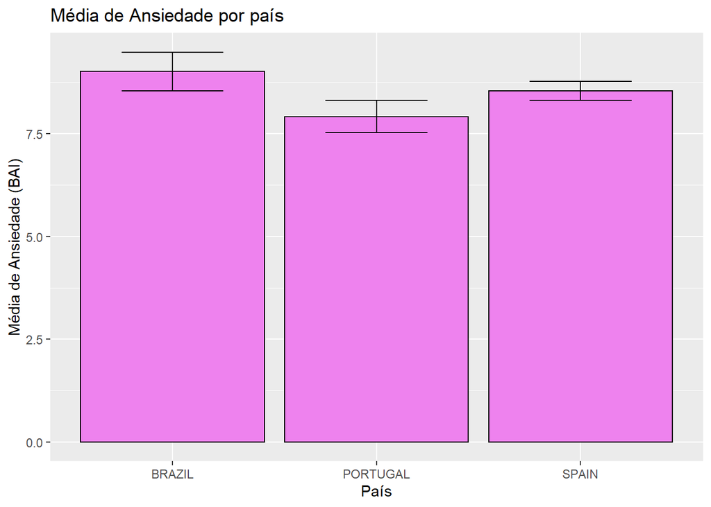

```r
# adicionando outros elementos ao gráfico (barras de erro)
ggplot(dataset,
       aes(x=country, y=bai_sum)) +
  geom_bar(stat = "summary",
           fun = mean,
           fill = "violet",
           color = "black",
           na.rm = TRUE) +
  stat_summary(geom = "errorbar", fun.data = mean_se,width = 0.5) +
  labs(title = "Média de Ansiedade por país",
       x = "País", y = "Média de Ansiedade (BAI)")
```

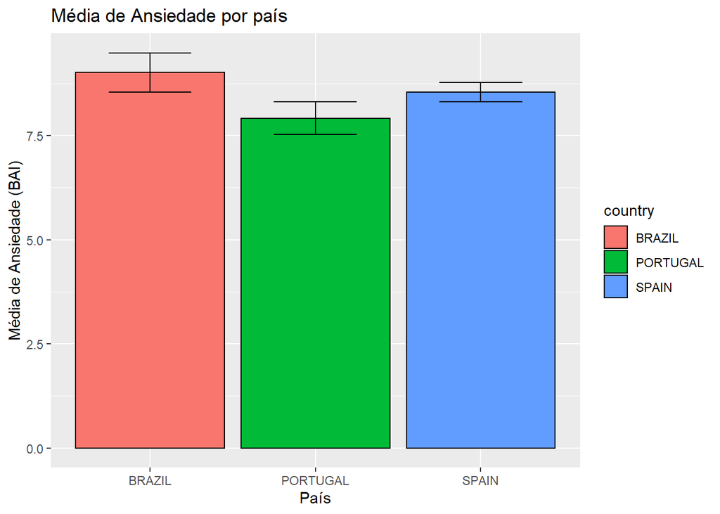

```r
# se modificar a posição do argumento fill, para dentro de aes e com o critério country... o gráfico fica colorido por país.
ggplot(dataset,
       aes(x=country, y=bai_sum,fill = country)) +
  geom_bar(stat = "summary",
           fun = mean,
           color = "black",
           na.rm = TRUE) +
  stat_summary(geom = "errorbar", fun.data = mean_se,width = 0.5) +
  labs(title = "Média de Ansiedade por país",
       x = "País", y = "Média de Ansiedade (BAI)")
```

### Gráfico de setor (polar, pizza ou torta)

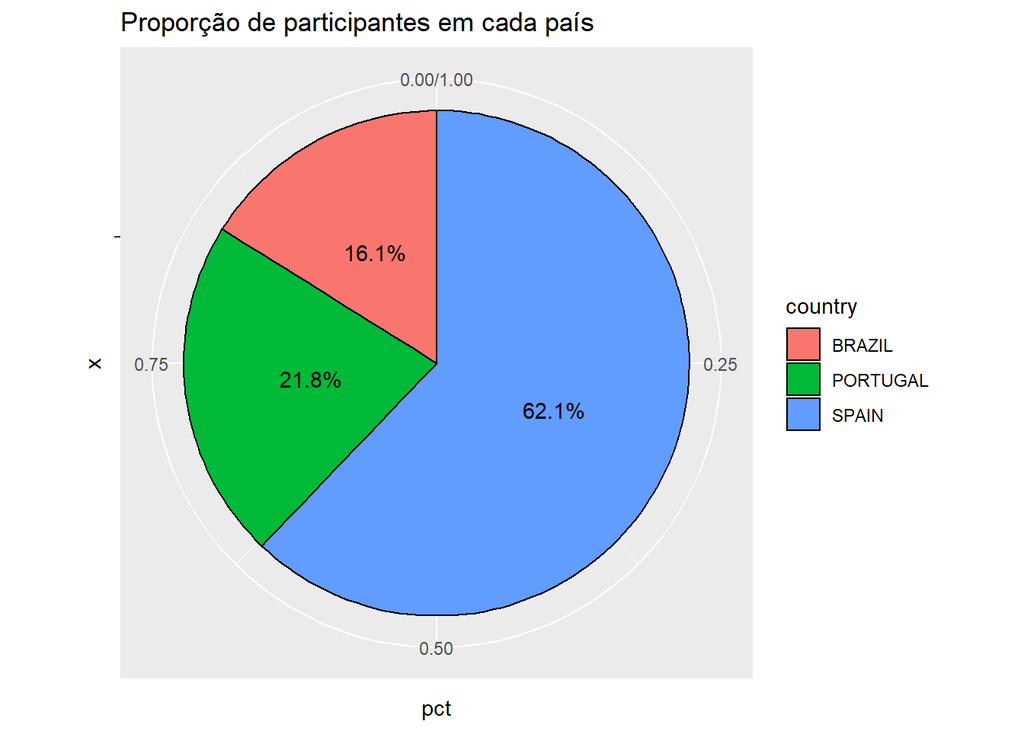

```r
dataset %>%
  count(country) %>%
  mutate(pct = n/sum(n)) %>%
  ggplot(.,aes(x = "", y = pct, fill = country)) +
  geom_col(color = "black") +
  geom_text(aes(label = scales::percent(round(pct,3))),
            position = position_stack(vjust = 0.5)) +
  coord_polar(theta = "y") +
  labs(title = "Proporção de participantes em cada país")
```

### Gráficos para descrição de distribuição ou variabilidade

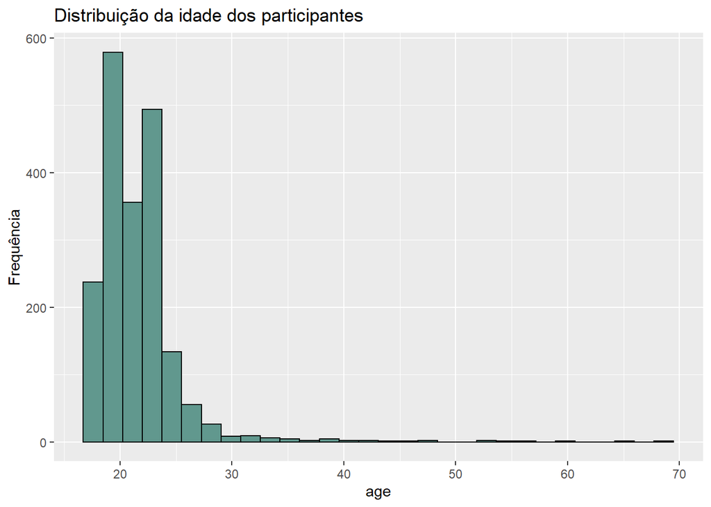

```r
# Histograma
ggplot(data = dataset, aes(x = age)) +
  geom_histogram(bins = 30,color = "black", fill = "#61988E") +
  labs(y = "Frequência",
    title = "Distribuição da idade dos participantes")
```

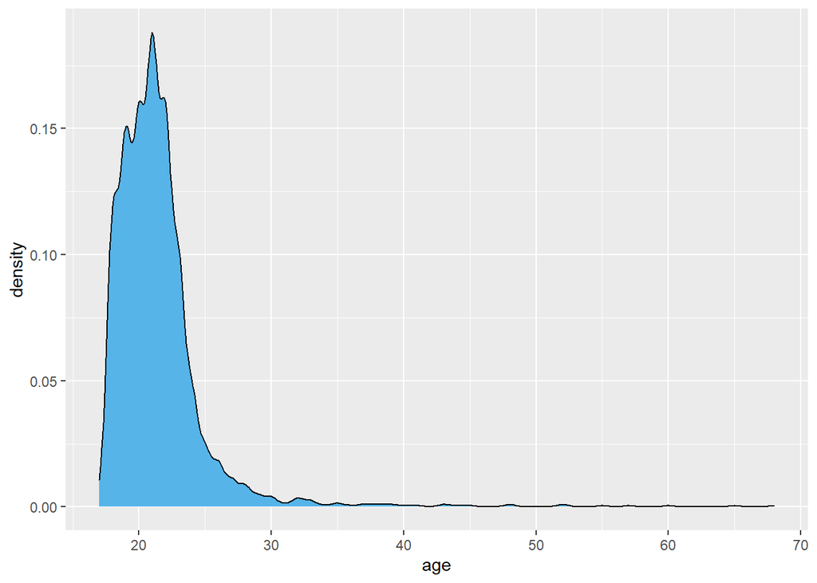

```r
# Densidade
ggplot(data = dataset, aes(age)) +
  geom_density(fill = "#56b4e9") +
  labs("Distribuição da idade dos participantes")
```

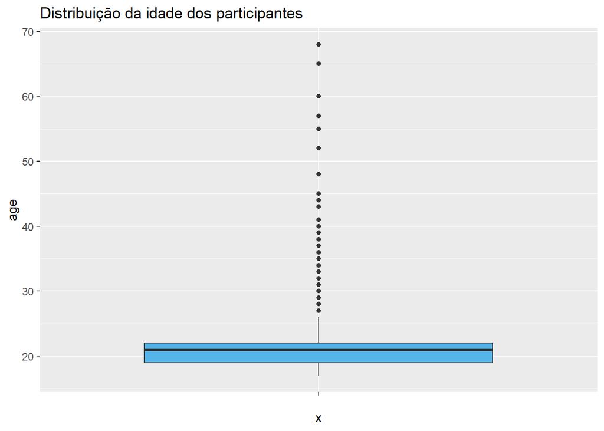

```r
# Boxplot (diagrama de caixa e bigode)
## Uma variável continua
ggplot(data = dataset, aes(y=age,x="")) +
  geom_boxplot(fill = "#56b4e9") +
  labs(title = "Distribuição da idade dos participantes")
```

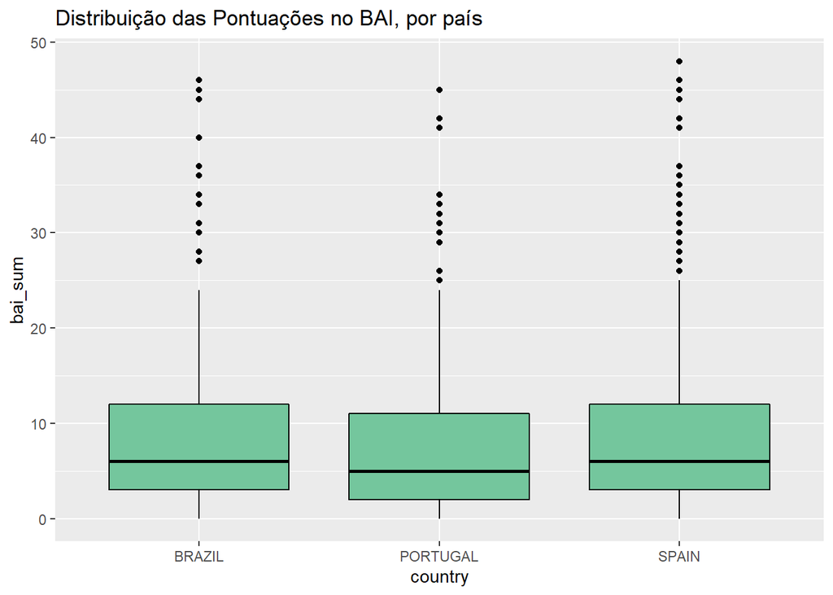

```r
## uma variável continua e uma categórica (discreta)
## no caso, bai_sum por país.
ggplot(dataset,aes(x=country, y=bai_sum)) +
  geom_boxplot(color = "black", fill = "#74c69d") +
  labs(title = "Distribuição das Pontuações no BAI, por país")
```

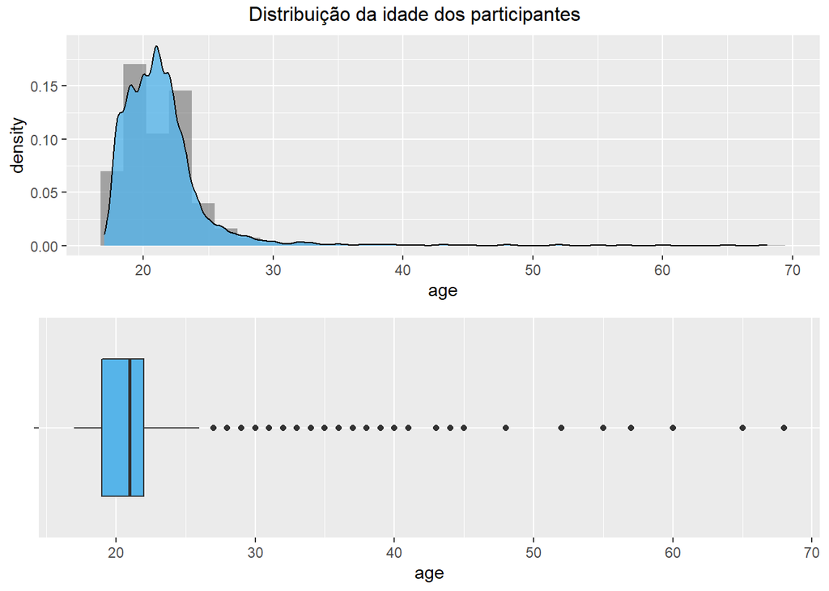

```r
# Combinação de gráficos usando o grid.arrange do pacote gridExtra

gridExtra::grid.arrange(

# Gráfico 1
ggplot(data = dataset, aes(age)) +
  geom_histogram(aes(y=..density..), alpha = 0.5, position = "identity") +
  geom_density(alpha = 0.8, fill = "#56b4e9") +
  labs("Distribuição da idade dos participantes"),
# Gráfico 2
ggplot(data = dataset, aes(y=age,x="")) +
  geom_boxplot(fill = "#56b4e9") +
  labs(x = "") +
  coord_flip(),
top = "Distribuição da idade dos participantes"
)
```